# Lab5-LogisticRegression[ameo-dataset]

## 16BCE1384

## Repository-link: https://github.com/raj1603chdry/CSE4020-MachineLearningLabs

### Importing the libraries

```python
import pandas as pd
import numpy as np
import matplotlib.pyplot as plt
import seaborn as sb
import math
%matplotlib inline
```

### Importing the dataset

```python
data = pd.read_csv('../datasets/ameo_dataset/processed_dataset/X.csv')
salary_category = pd.read_csv('../datasets/ameo_dataset/processed_dataset/y_cat.csv')
data['Salary'] = salary_category['Salary']
data.head(15)
```

|  | 10percentage | 12percentage | collegeGPA | English | Logical | Quant | Domain | ComputerProgramming | ElectronicsAndSemicon | ComputerScience | ... | GraduationYear_2017 | Gender_f | Gender_m | Degree_B.Tech/B.E. | Degree_M.Sc. (Tech.) | Degree_M.Tech./M.E. | Degree_MCA | CollegeTier_1 | CollegeTier_2 | Salary |
| --- | --- | --- | --- | --- | --- | --- | --- | --- | --- | --- | --- | --- | --- | --- | --- | --- | --- | --- | --- | --- | --- |
| 0 | 84.30 | 95.80 | 78.00 | 515 | 585 | 525 | 0.635979 | 445 | 0 | 0 | ... | 0 | 1 | 0 | 1 | 0 | 0 | 0 | 0 | 1 | (370000.0, 4000000.0] |
| 1 | 85.40 | 85.00 | 70.06 | 695 | 610 | 780 | 0.960603 | 0 | 466 | 0 | ... | 0 | 0 | 1 | 1 | 0 | 0 | 0 | 0 | 1 | (370000.0, 4000000.0] |
| 2 | 85.00 | 68.20 | 70.00 | 615 | 545 | 370 | 0.450877 | 395 | 0 | 0 | ... | 0 | 1 | 0 | 1 | 0 | 0 | 0 | 0 | 1 | (300000.0, 370000.0] |
| 3 | 85.60 | 83.60 | 74.64 | 635 | 585 | 625 | 0.974396 | 615 | 0 | 0 | ... | 0 | 0 | 1 | 1 | 0 | 0 | 0 | 1 | 0 | (370000.0, 4000000.0] |
| 4 | 78.00 | 76.80 | 73.90 | 545 | 625 | 465 | 0.124502 | 0 | 233 | 0 | ... | 0 | 0 | 1 | 1 | 0 | 0 | 0 | 0 | 1 | (180000.0, 300000.0] |
| 5 | 89.92 | 87.00 | 76.32 | 560 | 555 | 620 | 0.000000 | 645 | 0 | 407 | ... | 0 | 0 | 1 | 1 | 0 | 0 | 0 | 0 | 1 | (180000.0, 300000.0] |
| 6 | 86.08 | 67.50 | 72.98 | 590 | 435 | 380 | 0.356536 | 405 | 0 | 346 | ... | 0 | 0 | 1 | 1 | 0 | 0 | 0 | 0 | 1 | (180000.0, 300000.0] |
| 7 | 92.00 | 91.00 | 85.80 | 545 | 555 | 590 | 0.829585 | 0 | 0 | 0 | ... | 0 | 0 | 1 | 1 | 0 | 0 | 0 | 1 | 0 | (370000.0, 4000000.0] |
| 8 | 90.00 | 91.20 | 85.03 | 615 | 670 | 530 | 0.694479 | 735 | 366 | 0 | ... | 0 | 0 | 1 | 1 | 0 | 0 | 0 | 1 | 0 | (370000.0, 4000000.0] |
| 9 | 77.00 | 72.20 | 78.00 | 605 | 565 | 545 | 0.493596 | 385 | 324 | 0 | ... | 0 | 0 | 1 | 1 | 0 | 0 | 0 | 0 | 1 | (180000.0, 300000.0] |
| 10 | 88.60 | 83.70 | 74.90 | 565 | 455 | 565 | 0.765674 | 485 | 0 | 0 | ... | 0 | 0 | 1 | 1 | 0 | 0 | 0 | 0 | 1 | (370000.0, 4000000.0] |
| 11 | 81.00 | 86.00 | 72.29 | 495 | 605 | 715 | 0.968237 | 605 | 0 | 0 | ... | 0 | 0 | 1 | 1 | 0 | 0 | 0 | 1 | 0 | (370000.0, 4000000.0] |
| 12 | 83.60 | 69.83 | 60.00 | 380 | 580 | 470 | 0.229482 | 0 | 266 | 0 | ... | 0 | 0 | 1 | 1 | 0 | 0 | 0 | 0 | 1 | (180000.0, 300000.0] |
| 13 | 60.80 | 62.40 | 60.00 | 495 | 425 | 645 | 0.538387 | 385 | 333 | 0 | ... | 0 | 0 | 1 | 1 | 0 | 0 | 0 | 0 | 1 | (180000.0, 300000.0] |
| 14 | 81.20 | 79.90 | 67.67 | 395 | 565 | 645 | 0.000000 | 495 | 0 | 376 | ... | 0 | 0 | 1 | 1 | 0 | 0 | 0 | 0 | 1 | (180000.0, 300000.0] |

15 rows × 71 columns

```python
data.columns
```

```
Index(['10percentage', '12percentage', 'collegeGPA', 'English', 'Logical',
       'Quant', 'Domain', 'ComputerProgramming', 'ElectronicsAndSemicon',
       'ComputerScience', 'MechanicalEngg', 'ElectricalEngg', 'TelecomEngg',
       'CivilEngg', 'conscientiousness', 'agreeableness', 'extraversion',
       'nueroticism', 'openess_to_experience', 'Specialization_CE',
       'Specialization_CS', 'Specialization_EC', 'Specialization_EL',
       'Specialization_ME', 'Specialization_other',
       'CollegeState_Andhra Pradesh', 'CollegeState_Assam',
       'CollegeState_Bihar', 'CollegeState_Chhattisgarh', 'CollegeState_Delhi',
       'CollegeState_Goa', 'CollegeState_Gujarat', 'CollegeState_Haryana',
       'CollegeState_Himachal Pradesh', 'CollegeState_Jammu and Kashmir',
       'CollegeState_Jharkhand', 'CollegeState_Karnataka',
       'CollegeState_Kerala', 'CollegeState_Madhya Pradesh',
       'CollegeState_Maharashtra', 'CollegeState_Meghalaya',
       'CollegeState_Orissa', 'CollegeState_Punjab', 'CollegeState_Rajasthan',
       'CollegeState_Sikkim', 'CollegeState_Tamil Nadu',
       'CollegeState_Telangana', 'CollegeState_Union Territory',
       'CollegeState_Uttar Pradesh', 'CollegeState_Uttarakhand',
       'CollegeState_West Bengal', 'GraduationYear_0', 'GraduationYear_2007',
       'GraduationYear_2009', 'GraduationYear_2010', 'GraduationYear_2011',
       'GraduationYear_2012', 'GraduationYear_2013', 'GraduationYear_2014',
       'GraduationYear_2015', 'GraduationYear_2016', 'GraduationYear_2017',
       'Gender_f', 'Gender_m', 'Degree_B.Tech/B.E.', 'Degree_M.Sc. (Tech.)',
       'Degree_M.Tech./M.E.', 'Degree_MCA', 'CollegeTier_1', 'CollegeTier_2',
       'Salary'],
      dtype='object')
```

### Visualizing the dataset

**Selecting a few attributes for better visualisation**

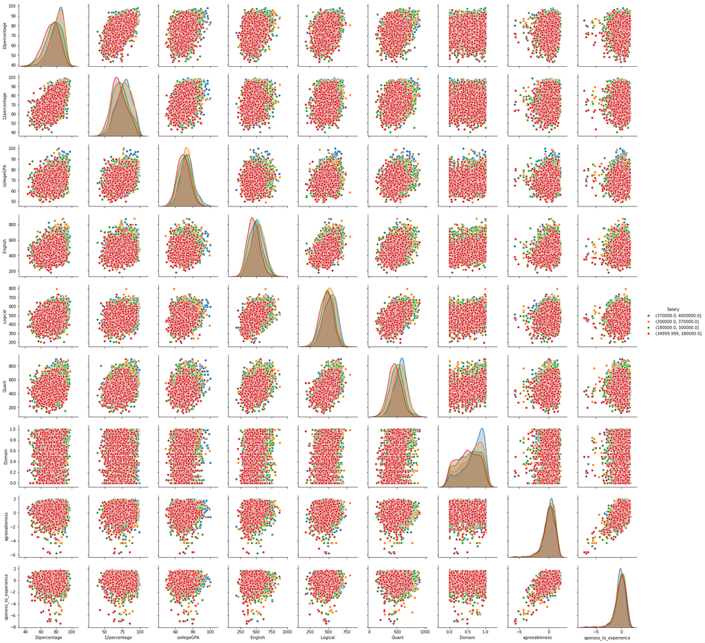

```python
cols = ['10percentage',
        '12percentage',
        'collegeGPA',
        'English',
        'Logical',
        'Quant',
        'Domain',
        'agreeableness',
        'openess_to_experience']
sb.pairplot(data,vars = cols, hue='Salary')
```

**The above pairplot shows that the different salary categories overlap a lot. Therefore, any linear classifier won't be able to produce good results. The same was the case in the experiment of perceptron and linear regression. The overlapping datapoints clearly state that we have to use a model that can deal with non-linear dataset easily.**

**Assigning class labels to the different salary categories**

```python
data.loc[data['Salary']=='(34999.999, 180000.0]','Salary']=1
data.loc[data['Salary']=='(180000.0, 300000.0]','Salary']=2
data.loc[data['Salary']=='(300000.0, 370000.0]','Salary']=3
data.loc[data['Salary']=='(370000.0, 4000000.0]','Salary']=4
y = data['Salary']
```

### Performing the experiment

**Plotting the salary distribution between 'Domain' and 'Agreeableness'**

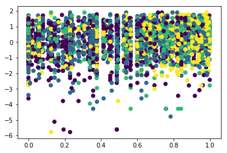

```python
plt.scatter(data['Domain'],data['agreeableness'],c=y)
```

**The above plot shows that the dataset is very dense and high non-linearity is present in it**

**Function to display the datapoints and the decision regions for the different salary categories. It also encircles the different points that are used as test points**

```python
from matplotlib.colors import ListedColormap
def plot_decision_regions(X, y, classifier,test_idx=None, resolution=0.02):
    # setup marker generator and color map
    markers = ('s', 'x', 'o', '^', 'v')
    colors = ('red', 'blue', 'lightgreen', 'gray', 'cyan')
    cmap = ListedColormap(colors[:len(np.unique(y))])

    # plot the decision surface
    x1_min, x1_max = X[:, 0].min() - 1, X[:, 0].max() + 1
    x2_min, x2_max = X[:, 1].min() - 1, X[:, 1].max() + 1
    xx1, xx2 = np.meshgrid(np.arange(x1_min, x1_max, resolution),
                         np.arange(x2_min, x2_max, resolution))
    Z = classifier.predict(np.array([xx1.ravel(), xx2.ravel()]).T)
    Z = Z.reshape(xx1.shape)

    plt.contourf(xx1, xx2, Z, alpha=0.4, cmap=cmap)
    plt.xlim(xx1.min(), xx1.max())
    plt.ylim(xx2.min(), xx2.max())

    # plot class samples
    for idx, cl in enumerate(np.unique(y)):
        plt.scatter(x=X[np.where(y == cl), 0], y=X[np.where(y == cl), 1], alpha=0.8, c=cmap(idx), marker=markers[idx], label=cl)

    # highlight test samples
    if test_idx:
        X_test, y_test = X[test_idx, :], y[test_idx]
        plt.scatter(X_test[:, 0], X_test[:, 1], c='',edgecolor='black',alpha=1.0, linewidths=1, marker='o',s=55, label='test set')
```

**The function below, standardizes the datapoints, splits the dataset into 7:3 ratio for training set and test set. Trains the Logistic Regression model on the training set and predicts the accuracy score using the test set. Then it plots the decision region for the model along with the datapoints in both the training set and test set**

```python
from sklearn.model_selection import train_test_split
from sklearn.preprocessing import StandardScaler
from sklearn.linear_model import LogisticRegression
from sklearn.metrics import accuracy_score

def standarize_and_plot_Logistic(X, y, xlab, ylab):
    X_train,X_test,y_train,y_test = train_test_split(X,y,test_size=0.3, random_state=0)

    sc = StandardScaler()
    sc.fit(X_train)
    X_train_std = sc.transform(X_train)
    X_test_std = sc.transform(X_test)
    X_combined_std = np.vstack((X_train_std, X_test_std))
    y_combined = np.hstack((y_train, y_test))

    lr = LogisticRegression(C=1000.0, random_state=0)
    lr.fit(X_train_std, y_train)

    y_pred = lr.predict(X_test_std)

#     print(lr.predict_proba(X_test_std[0,:]))

    plot_decision_regions(X_combined_std, y_combined, classifier=lr, test_idx=range(105,200,5))
    plt.xlabel(xlab + ' [standardized]')
    plt.ylabel(ylab + ' [standardized]')
    plt.legend(loc='upper left')
    plt.show()

    print('Accuracy: %.2f%%' % (accuracy_score(y_test, y_pred)*100))
```

**Applying Logistic Regression to 'Domain' and 'Agreeableness'**

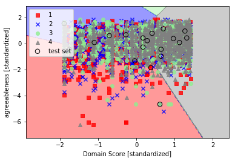

```
Accuracy: 32.50%
```

```python
X = data.as_matrix(columns = ['Domain', 'agreeableness'])
standarize_and_plot_Logistic(X,y,'Domain Score', 'agreeableness')
```

**We get 32.5% accuracy due to the huge overlapping of the datapoints.**

**Applying Logistic Regression for 'Agreeableness' and 'Openess_to_experience'**

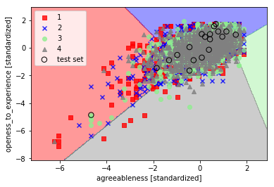

```
Accuracy: 26.08%
```

```python
X = data.as_matrix(columns = ['agreeableness', 'openess_to_experience'])
standarize_and_plot_Logistic(X,y,'agreeableness', 'openess_to_experience')
```

**Applying Logistic Regression for 'Domain' and 'Openess_to_experience'**

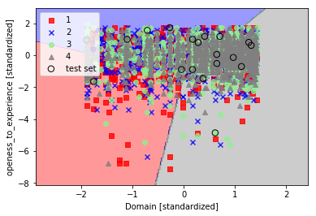

```
Accuracy: 32.33%
```

```python
X = data.as_matrix(columns = ['Domain', 'openess_to_experience'])
standarize_and_plot_Logistic(X,y,'Domain', 'openess_to_experience')
```

**Applying Logistic Regression for '10percentage' and 'Quant'**

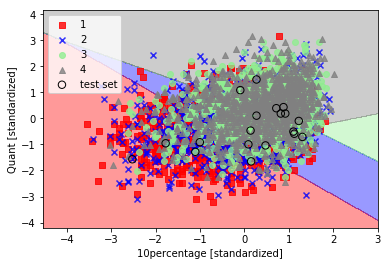

```
Accuracy: 36.00%
```

```python
X = data.as_matrix(columns = ['10percentage', 'Quant'])
standarize_and_plot_Logistic(X,y,'10percentage', 'Quant')
```

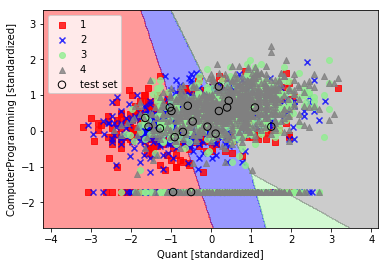

```
Accuracy: 36.75%
```

```python
X = data.as_matrix(columns = ['Quant', 'ComputerProgramming'])
standarize_and_plot_Logistic(X,y,'Quant', 'ComputerProgramming')
```